# Exploration of NOAA Storm Database and Analysis of Severe Weather Events

## Synopsis

By using the [NOAA Storm Database](https://www.ncdc.noaa.gov/stormevents/) ([csv](https://d396qusza40orc.cloudfront.net/repdata%2Fdata%2FStormData.csv.bz2)) and corresponding [documentation](https://d396qusza40orc.cloudfront.net/repdata%2Fpeer2_doc%2Fpd01016005curr.pdf) we are able to better understand the effects of severe weather. We do a brief analysis grouping and plotting severe weather events by category and resulting quantitative fields.

It is useful to understand how different factors relate to one and other as it may be helpful in preventing or preparing for such disasters in the future.

## Data Processing

Load required libararies

```r
library(ggplot2)
```

```r
datapath = "data/StormData.csv.bz2"
dir.create(dirname(datapath), showWarnings = FALSE)
if (! file.exists(datapath))
    download.file(
        "https://d396qusza40orc.cloudfront.net/repdata%2Fdata%2FStormData.csv.bz2", datapath)
```

The data should be in the same directory as the script. Read in the data set (902,297 observations) with typing on initial load to save time.

```r
# Initial data frame
df <- read.csv(datapath, header = TRUE, sep = ",",
               colClasses = c("numeric", "character", "character", "character",
                              "numeric", "character", "character", "character",
                              "numeric", "character", "character", "character",
                              "character", "numeric", "character", "character",
                              "character", "character", "numeric", "numeric",
                              "character", "numeric", "numeric", "numeric",
                              "numeric", "character", "numeric", "character",
                              "character", "character", "character", "numeric",
                              "numeric", "numeric", "numeric", "character",
                              "numeric"))
```

For this study, we are only interested in the following four categories. This brings the row count of the data frame down to 254,633 observations.

```r
# Small (filtered) data frame
sf <- df[df$FATALITIES > 0
         | df$INJURIES > 0
         | df$PROPDMG > 0
         | df$CROPDMG > 0,]
```

Now, we would like to group the `EVTYPE` (event type) into a categorial variable. There are six large categories: `Convection`, `Extreme Temperatures`, `Flood`, `Marine`, `Cyclone`, and `Winter`. I have devised a regular expression to cover all the major possibilities for the six categories. In addition to those, `Other` covers everything else.

```r
names <- c("Convection", "Extreme Temperatures", "Flood", "Marine",
           "Cyclone", "Winter")
expressions <- c(
    paste("?.*lighting|lightn|ligntning|tornado|torndao|wind|tstm|thunder|wnd",
          "|hail|turbulence|gustnado?.*", sep = ""),
    "?.*cold|heat|warm|temperature|thermia?.*",
    "?.*flood|rising|stream fld?.*",
    "?.*coastal|tsunami|current|swells|tide|wave|seas|surf|high water?.*",
    "?.*cyclone|hurricane|typhoon?.*",
    "?.*wint|ice|avalan|sleet|snow|freez|blizz|frost|glaze|mixed?.*")
for (i in 1:length(names)) {
    mask <- grepl(expressions[i], sf$EVTYPE, ignore.case = TRUE)
    sf[mask, "category"] = names[i]
}
mask <- is.na(sf$category)
sf[mask, "category"] = "Other"
```

```r
sf$propertydamageEXP = 1
patterns <- c("h|H", "k|K", "m|M", "b|B")
values <- c(100, 1000, 1e+06, 1e+09)
for (i in 1:length(values)) {
    mask <- grepl(patterns[i], sf$PROPDMGEXP, ignore.case = TRUE)
    sf[mask, "propertydamageEXP"] = values[i]
}
sf$propertydamage = sf$PROPDMG * sf$propertydamageEXP

sf$cropdamageEXP = 1
patterns <- c("k|K", "m|M", "b|B")
values <- c(100, 1e+06, 1e+09)
for (i in 1:length(values)) {
    mask <- grepl(patterns[i], sf$CROPDMGEXP, ignore.case = TRUE)
    sf[mask, "cropdamageEXP"] = values[i]
}
sf$cropdamage = sf$CROPDMG * sf$cropdamageEXP
```

## Results

### Weather events that cause the largest number of incidents

Create an `incidents` column that is comprised of the number of fatalities and injuries. This will be used to discover which severe weather events have the highest number of incidents.

```r
sf$incidents = sf$FATALITIES + sf$INJURIES
```

Create a frame that shows the name of the event with corresponding number of incidents. It shows that `Convection` events have the greatest number of incidents.

```r
# Incident data
inc <- aggregate(list(incidents = sf$incidents),
                 by = list(event = sf$category),
                 FUN = sum, na.rm = TRUE)
```

A corresponding plot showing the name of event and number of incidents.

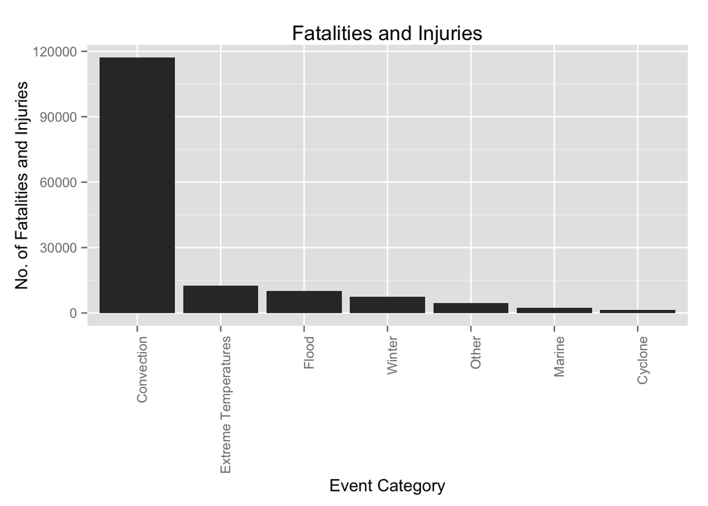

```r
inc$event <- reorder(inc$event, -inc$incidents)

ggplot(inc, aes(y = incidents)) +
    theme(axis.text.x = element_text(angle = 90, hjust = 1)) +
    geom_bar(aes(x = event), data = inc, stat = "identity") +
    ggtitle("Fatalities and Injuries") +
    xlab("Event Category") +
    ylab("No. of Fatalities and Injuries")
```

### Weather events that cause the largest amount of damage

Create a `damage` field that contains damage to property as well as crops. This is so that we can find out which events cause the most dollar damage. This column is in billions of dollars.

```r
sf$damage = ((sf$propertydamage + sf$cropdamage) / 1e+09)
```

Create a frame that has name of event corresponding to the dollar amount of damage (in billions). The frame shows that `Flood` results in the greatest amount of dollar damage.

```r
# Damage data frame
dmg <- aggregate(list(damage = sf$damage),
                 by = list(event = sf$category),
                 FUN = sum, na.rm = TRUE)
```

A corresponding plot showing the name of event and billions of dollars in damage.

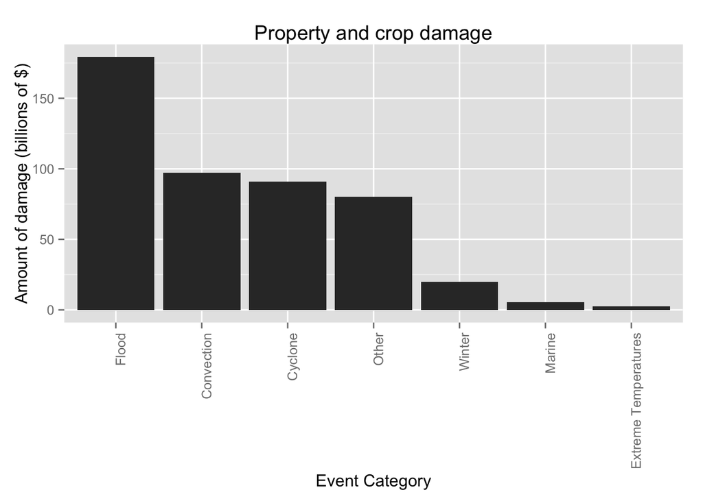

```r
dmg$event <- reorder(dmg$event, -dmg$damage)

ggplot(dmg, aes(y = damage)) +
    theme(axis.text.x = element_text(angle = 90, hjust = 1)) +
    geom_bar(aes(x = event), data = dmg, stat = "identity") +
    ggtitle("Property and crop damage") +
    xlab("Event Category") +
    ylab("Amount of damage (billions of $)")
```